# Two-sample testing

```r
library(tidyverse)
library(emmeans)
library(rstatix)
library(WRS2)
library(ggstatsplot)
```

# Two-sample testing, t-test examples

## Non-parametric examples

There are two simple tests for comparing two sample means from populations: the *Student’s t-test* (parametric) and the Wilcoxon rank-sum test fro errors not normally distributed (non-parametric). But lets start considering the assumptions for these tests, like the test for difference in the samples variances.

## Comparing Two Variances

Before we do a test to compare two sample means, we need to compare two variances. All we do is to divide the large variance by the small variance. If the variances are the same we will get a ratio of 1, obviously. This can be done estimating the critical value of the variance ratio, for this we use the *Fisher’s F* distribution. If the test statistic is larger than the critical value (*F*), we reject the null hypothesis. For this test the null hypothesis is assuming the the variances ration is equal to one. In R. there is a build in function called `var.test`, and rstatix has a Levene’s test. We will include some variance tests in the examples bellow.

## Wilcoxon Rank-Sum Test

This is a non-parametric alternative to Student’s *t* test, this test can be used if the error are non-normal. R has a build-in function `wilcox.test` (and R packages too), that make the procedure without the need to estimate tables pf critical values of the Wilcoxon rank sums.

**Example 1** The purpose of a study by Tam et al. was to investigate wheelchair maneuvering in individuals with lower-level spinal cord injury (SCI) and healthy controls (C). Subjects used a modified wheelchair to incorporate a rigid seat surface to facilitate the specified experimental measurements. Interface pressure measurement was recorded by using a high-resolution pressure-sensitive mat with a spatial resolution of four sensors per square centimeter taped on the rigid seat support. During static sitting conditions, average pressures were recorded under the ischial tuberosities (the bottom part of the pelvic bones). The data for measurements of the left ischial tuberosity (in mm Hg) for the SCI and control groups are shown in EXA_C07_S03_02.csv. We wish to know if we may conclude, on the basis of these data, that, in general, healthy subjects exhibit lower pressure than SCI subjects.

*Result* We are going to run two solutions, there is a parametric solution using R’s `t.test()` in my [Statistics course page](https://fabarrios.github.io/ProbEstad/Hipotesis/Hipotesis.html), here we are going to use the rstatix for non-parametric solution and WRS2 for a robust solution. First to use the pipeline structure in rstatix we need to wrangle the data a little.

```r
SCI_con <- read_csv("~/DropBox/GitHub/ProbEstad/DataSets/ch07_all/EXA_C07_S03_02.csv",
                    show_col_types = FALSE)

SCI_con
```

```
## # A tibble: 10 × 2
##    CONTROL   SCI
##      <dbl> <dbl>
##  1     131    60
##  2     115   150
##  3     124   130
##  4     131   180
##  5     122   163
##  6     117   130
##  7      88   121
##  8     114   119
##  9     150   130
## 10     169   148
```

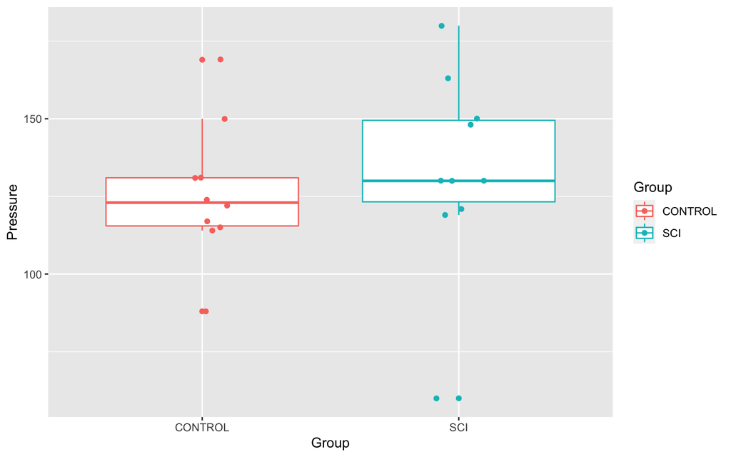

```r
SCI_long <- SCI_con %>%
  pivot_longer(cols = everything(), names_to = "Group", values_to = "Pressure")

SCI_long <- SCI_long %>%
  mutate( Group = factor(Group) )

SCI_long <- SCI_long %>%
  mutate( Group = Group %>% fct_relevel("CONTROL","SCI") )

ggplot(SCI_long, aes(x = Group, y = Pressure, color = Group)) +
  geom_boxplot() +
  geom_jitter(height = .1, width = .1)
```

```r
var.test(Pressure ~ Group, data = SCI_long)
```

```
##
##  F test to compare two variances
##
## data:  Pressure by Group
## F = 0.45981, num df = 9, denom df = 9, p-value = 0.2626
## alternative hypothesis: true ratio of variances is not equal to 1
## 95 percent confidence interval:
##  0.1142097 1.8511823
## sample estimates:
## ratio of variances
##          0.4598075
```

```r
SCI_long %>% levene_test(Pressure ~ Group, center = median)
```

```
## # A tibble: 1 × 4
##     df1   df2 statistic     p
##   <int> <int>     <dbl> <dbl>
## 1     1    18     0.486 0.495
```

```r
SCI_long.t.Test <- t.test(Pressure ~ Group,
                          data = SCI_long,
                          alternative = "less",
                          paired = FALSE,
                          var.equal = TRUE,
                          conf.level = 0.95)
SCI_long.t.Test
```

```
##
##  Two Sample t-test
##
## data:  Pressure by Group
## t = -0.56936, df = 18, p-value = 0.2881
## alternative hypothesis: true difference in means between group CONTROL and group SCI is less than 0
## 95 percent confidence interval:
##      -Inf 14.31935
## sample estimates:
## mean in group CONTROL     mean in group SCI
##                 126.1                 133.1
```

```r
SCI_long %>% cohens_d(Pressure ~ Group,
                      ref.group = "CONTROL",
                      var.equal = TRUE,
                      paired = FALSE,
                      hedges.correction = FALSE,
                      ci = FALSE,
                      conf.level = 0.95)
```

```
## # A tibble: 1 × 7
##   .y.      group1  group2 effsize    n1    n2 magnitude
## * <chr>    <chr>   <chr>    <dbl> <int> <int> <ord>
## 1 Pressure CONTROL SCI     -0.255    10    10 small
```

```r
SCL_wilcox <- SCI_long %>%
  wilcox_test(Pressure ~ Group,
              p.adjust.method = "holm",
              paired = FALSE,
              alternative = "less",
              conf.level = 0.95) %>%
  add_significance()

SCL_wilcox
```

```
## # A tibble: 1 × 8
##   .y.      group1  group2    n1    n2 statistic     p p.signif
##   <chr>    <chr>   <chr>  <int> <int>     <dbl> <dbl> <chr>
## 1 Pressure CONTROL SCI       10    10      38.5 0.202 ns
```

```r
SCI_long %>% wilcox_effsize(Pressure ~ Group)
```

```
## # A tibble: 1 × 7
##   .y.      group1  group2 effsize    n1    n2 magnitude
## * <chr>    <chr>   <chr>    <dbl> <int> <int> <ord>
## 1 Pressure CONTROL SCI      0.195    10    10 small
```

this answer for the estimate falls in the non-rejection region, the two groups are **not different**.

**Example 2** Can we conclude that patients with primary hypertension (PH), on the average, have higher total cholesterol levels than normotensive (NT) patients? This was one of the inquiries of interest for Rossi et al. In the table in EXR_C07_S03_04.csv there are total cholesterol measurements (mg/dl) for 133 PH patients and 41 NT patients. Can we conclude that PH patients have, on average, higher total cholesterol levels than NT patients? Let $\alpha = .05$.

```r
Hyper <- read_csv("~/DropBox/GitHub/ProbEstad/DataSets/ch07_all/EXR_C07_S03_04.csv", show_col_types = FALSE)

Hyper
```

```
## # A tibble: 174 × 2
##    Length Group
##     <dbl> <dbl>
##  1    207     1
##  2    172     1
##  3    191     1
##  4    221     1
##  5    203     1
##  6    241     1
##  7    208     1
##  8    199     1
##  9    185     1
## 10    235     1
## # … with 164 more rows
```

We have the data format in long format so we can do “data and formula”, nevertheless we need to “factor” the data and the levels are fine (1, 2) making the hypertensive the 1 = HT and the normotensive 2 = NT.

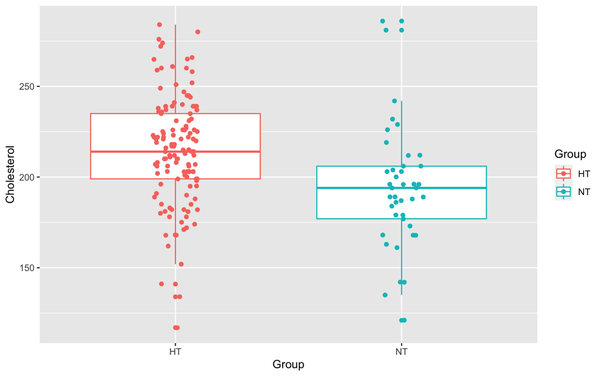

```r
Hyper <- Hyper %>% rename(Cholesterol = Length)

Hyper_n <- Hyper %>% mutate(Group = case_when(
  Group == 1 ~ "HT",
  Group == 2 ~ "NT"
))

Hyper_n <- Hyper_n %>%
  mutate(Group = factor(Group) )

ggplot(Hyper_n, aes(x = Group, y = Cholesterol, color = Group)) +
  geom_boxplot() +
  geom_jitter(height = .1, width = .1)
```

We start this example estimating a parametric t-test, from rstatix, to use the same data format for the non-parametric test. We initiate by estimating the `var.test()`Then we run the Wilcoxon test from rstatix. Finally, in the robust statistical estimates section we use a yuen test and other examples.

```r
# estimate Null hypothesis is var1/var2 = 1
var.test(Cholesterol ~ Group, data = Hyper_n)
```

```
##
##  F test to compare two variances
##
## data:  Cholesterol by Group
## F = 0.80512, num df = 132, denom df = 40, p-value = 0.3639
## alternative hypothesis: true ratio of variances is not equal to 1
## 95 percent confidence interval:
##  0.4689967 1.2900776
## sample estimates:
## ratio of variances
##          0.8051205
```

```r
Hyper_base_t.Test <- t.test(Cholesterol ~ Group,
                           data = Hyper_n,
                           paired = FALSE,
                           var.equal = TRUE,
                           alternative = "greater",
                           conf.level = 0.95)
Hyper_base_t.Test
```

```
##
##  Two Sample t-test
##
## data:  Cholesterol by Group
## t = 3.9531, df = 172, p-value = 5.624e-05
## alternative hypothesis: true difference in means between group HT and group NT is greater than 0
## 95 percent confidence interval:
##  12.51683      Inf
## sample estimates:
## mean in group HT mean in group NT
##         214.7143         193.1951
```

```r
Hyper_t_test <- Hyper_n %>%
  t_test(Cholesterol ~ Group,
         p.adjust.method = "holm",
         var.equal = TRUE,
         paired = FALSE,
         alternative = "greater",
         conf.level = 0.95) %>%
  add_significance()

Hyper_t_test
```

```
## # A tibble: 1 × 9
##   .y.         group1 group2    n1    n2 statistic    df         p p.signif
##   <chr>       <chr>  <chr>  <int> <int>     <dbl> <dbl>     <dbl> <chr>
## 1 Cholesterol HT     NT       133    41      3.95   172 0.0000562 ****
```

```r
Hyper_n %>% cohens_d(Cholesterol ~ Group,
                      ref.group = "HT",
                      var.equal = TRUE,
                      paired = FALSE,
                      hedges.correction = TRUE,
                      ci = TRUE,
                      conf.level = 0.95)
```

```
## # A tibble: 1 × 9
##   .y.         group1 group2 effsize    n1    n2 conf.low conf.high magnitude
## * <chr>       <chr>  <chr>    <dbl> <int> <int>    <dbl>     <dbl> <ord>
## 1 Cholesterol HT     NT       0.703   133    41     0.33      1.15 moderate
```

```r
# And the non-parametric example
Hyper_wilcox <- Hyper_n %>%
  wilcox_test(Cholesterol ~ Group,
              p.adjust.method = "holm",
              paired = FALSE,
              alternative = "greater",
              conf.level = 0.95) %>%
  add_significance()

Hyper_wilcox
```

```
## # A tibble: 1 × 8
##   .y.         group1 group2    n1    n2 statistic         p p.signif
##   <chr>       <chr>  <chr>  <int> <int>     <dbl>     <dbl> <chr>
## 1 Cholesterol HT     NT       133    41      3917 0.0000122 ****
```

## Robust statisticlal Methods

Now for the **Example 1** we can use a robust statistic test for a two-sample trimmed mean test from the WRS2 package, the `yuen` test. The WRS2 package also has a bootstrap version of this test too `yuenbt`

```r
SCL_yuen <- yuen(Pressure ~ Group, data = SCI_long, side = FALSE)
SCL_yuen
```

```
## Call:
## yuen(formula = Pressure ~ Group, data = SCI_long, side = FALSE)
##
## Test statistic: 1.4111 (df = 7.92), p-value = 0.19627
##
## Trimmed mean difference:  -11.5
## 95 percent confidence interval:
## -30.3265     7.3265
##
## Explanatory measure of effect size: 0.39
```

For the robust statistics, as for the non-parametric (and parametric) statistics, there is no difference in the measured pressure for the differen groups.

For the **Example 2** we use a yuen test and other robust tests that may correct for outliers or “large” values. For the effect size function for trimmed means can be estimated by AKP (Algina, Keselman, Penfield) robust version of the Cohen’s *d*, where the rule of the effect sizes go as 0.2, 0.5 and 0.8 correspond to small, medium and large effects.

```r
Hyper_yuen <- yuen(Cholesterol ~ Group, data = Hyper_n, side = FALSE)
Hyper_yuen
```

```
## Call:
## yuen(formula = Cholesterol ~ Group, data = Hyper_n, side = FALSE)
##
## Test statistic: 4.778 (df = 42.55), p-value = 2e-05
##
## Trimmed mean difference:  23.56099
## 95 percent confidence interval:
## 13.6133     33.5087
##
## Explanatory measure of effect size: 0.56
```

```r
# Effect size AKP (Algina, Keselman, Penfield)
akp.effect(Cholesterol ~ Group, data = Hyper_n)
```

```
## $AKPeffect
## [1] 0.8684128
##
## $AKPci
## [1] 0.465938 1.395940
##
## $alpha
## [1] 0.05
##
## $call
## akp.effect(formula = Cholesterol ~ Group, data = Hyper_n)
##
## attr(,"class")
## [1] "AKP"
```

### “Nice graphics”

Now we can use an interesting R package that produces quite interesting graphics `ggstatsplot` we will make more examples of this package to solve ANOVA examples.

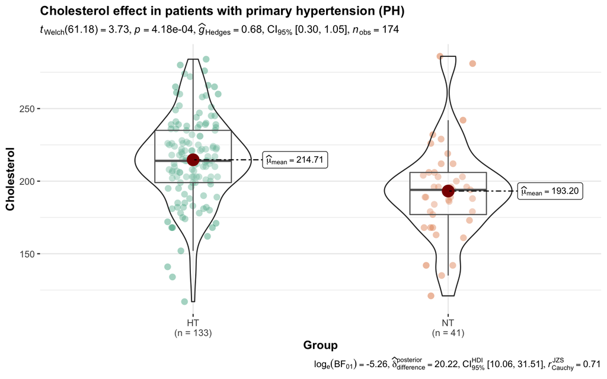

```r
# from the example 2 for the patients with primary hypertension (PH)
ggbetweenstats(
  data = Hyper_n,
  x    = Group,
  y    = Cholesterol,
  plot.type = "boxviolin",
  type = "parametric",
  p.adjust.method = "holm",
  title = "Cholesterol effect in patients with primary hypertension (PH)"
)
```

## Paired Comparisons

The objective of paired comparisons tests is to eliminate a maximum number of sources of extraneous variation by making the pairs similar with respect to as many variables as possible. Instead of performing the analysis with individual observations, paired observations run the comparison on the differences, of the two observations per subject as the variable of interest.

**Example 3** The purpose of an investigation by Morley et al. was to evaluate the analgesic effectiveness of a daily dose of oral methadone in patients with chronic neuropathic pain syndromes. The researchers used a visual analogue scale (*0–100 mm*, higher number indicates higher pain) ratings for maximum pain intensity over the course of the day. Each subject took either *20 mg* of methadone or a placebo each day for 5 days. Subjects did not know which treatment they were taking. The following table gives the *mean maximum pain* intensity scores for the 5 days on methadone and the 5 days on placebo. Do these data provide sufficient evidence, at the *.05* level of significance, to indicate that in general the maximum pain intensity is *lower* on days when methadone is taken? (Data is in EXR_C07_S04_03.csv).

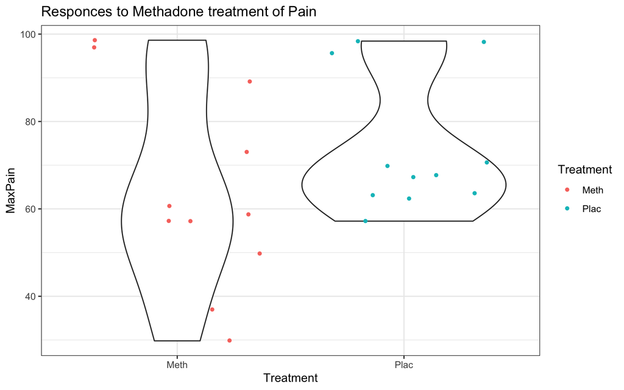

```r
# Reading the data
MaxPain <- read_csv("~/DropBox/GitHub/ProbEstad/DataSets/ch07_all/EXR_C07_S04_03.csv", show_col_types = FALSE)

# adding a new column for the subject ID
MaxPain_new <- MaxPain %>% mutate(Subj = 1:11)

# to make the data long
MaxPain_new_long <- MaxPain_new %>%
  pivot_longer(cols = c("Plac", "Meth"), names_to = "Treatment", values_to = "MaxPain")

# Now we re-level the Treatment to Placebo and Methadone to force the order of factors
MaxPain_new_long <- MaxPain_new_long %>% mutate(factor(Treatment))

# A boxplot
MaxPain_new_long %>% ggplot(aes(x = Treatment, y = MaxPain)) +
    geom_violin() +
    geom_jitter(aes(color = Treatment), shape = 16, position = position_jitter(seed = 123)) +
    labs(title = "Responces to Methadone treatment of Pain") +
    theme_bw()
```

To solve this problems we use the `t.test()` with the `paired` flag set to `TRUE`

```r
# Using the base lib t.test
t.test(MaxPain ~ Treatment,
       data = MaxPain_new_long,
       alternative = "less",
       paired = TRUE,
       var.equal = TRUE,
       conf.level = 0.95)
```

```
##
##  Paired t-test
##
## data:  MaxPain by Treatment
## t = -3.1554, df = 10, p-value = 0.005119
## alternative hypothesis: true difference in means is less than 0
## 95 percent confidence interval:
##       -Inf -4.093522
## sample estimates:
## mean of the differences
##               -9.618182
```

```r
MaxPain_new_long %>% t_test(MaxPain ~ Treatment,
                            alternative = "less",
                            p.adjust.method = "holm",
                            paired = TRUE,
                            var.equal = TRUE,
                            conf.level = 0.95)
```

```
## # A tibble: 1 × 8
##   .y.     group1 group2    n1    n2 statistic    df       p
## * <chr>   <chr>  <chr>  <int> <int>     <dbl> <dbl>   <dbl>
## 1 MaxPain Meth   Plac      11    11     -3.16    10 0.00512
```

```r
# for the effect size with a d Cohen
MaxPain_new_long %>% cohens_d(MaxPain ~ Treatment,
                     paired = TRUE,
                     ref.group = "Plac",
                     var.equal = TRUE,
                     conf.level = 0.95)
```

```
## # A tibble: 1 × 7
##   .y.     group1 group2 effsize    n1    n2 magnitude
## * <chr>   <chr>  <chr>    <dbl> <int> <int> <ord>
## 1 MaxPain Plac   Meth     0.951    11    11 large
```

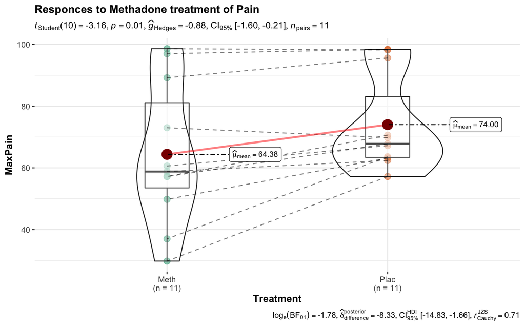

```r
# Now the nice graph
# from the example 2 for the patients with primary hypertension (PH)
ggwithinstats(
  data = MaxPain_new_long,
  x    = Treatment,
  y    = MaxPain,
  plot.type = "boxviolin",
  type = "parametric",
  p.adjust.method = "holm",
  pairwise.comparisons = TRUE,
  title = "Responces to Methadone treatment of Pain"
)
```